# Assignment1

Andrea Gilardi

2 5 2020

## Introduction

It is now possible to collect a large amount of data about personal movement using activity monitoring devices such as a Fitbit, Nike Fuelband, or Jawbone Up. These type of devices are part of the “quantified self” movement – a group of enthusiasts who take measurements about themselves regularly to improve their health, to find patterns in their behavior, or because they are tech geeks. But these data remain under-utilized both because the raw data are hard to obtain and there is a lack of statistical methods and software for processing and interpreting the data.

This assignment makes use of data from a personal activity monitoring device. This device collects data at 5 minute intervals through out the day. The data consists of two months of data from an anonymous individual collected during the months of October and November, 2012 and include the number of steps taken in 5 minute intervals each day.

The data for this assignment can be downloaded from the course web site:

```
Dataset: Activity monitoring data [52K]
```

The variables included in this dataset are:

[output not shown]

The dataset is stored in a comma-separated-value (CSV) file and there are a total of 17,568 observations in this dataset.

## Loading and preprocessing the data

Download data and unzip it into the pre-assigned directory

Load the data and check the structure of the dataset

```r
activity <- read.csv("activity.csv")
str(activity)
```

```
## 'data.frame':    17568 obs. of  3 variables:
##  $ steps   : int  NA NA NA NA NA NA NA NA NA NA ...
##  $ date    : Factor w/ 61 levels "2012-10-01","2012-10-02",..: 1 1 1 1 1 1 1 1 1 1 ...
##  $ interval: int  0 5 10 15 20 25 30 35 40 45 ...
```

## What is mean total number of steps taken per day?

1.Calculate the total number of steps taken per day - NA values excluded

```r
daysteps <- aggregate(steps ~ date, activity, sum, na.rm = TRUE )
daysteps
```

```
##          date steps
## 1  2012-10-02   126
## 2  2012-10-03 11352
## 3  2012-10-04 12116
## 4  2012-10-05 13294
## 5  2012-10-06 15420
## 6  2012-10-07 11015
## 7  2012-10-09 12811
## 8  2012-10-10  9900
## 9  2012-10-11 10304
## 10 2012-10-12 17382
## 11 2012-10-13 12426
## 12 2012-10-14 15098
## 13 2012-10-15 10139
## 14 2012-10-16 15084
```

[output cut: 39 more lines]

2.If you do not understand the difference between a histogram and a barplot, research the difference between them. Make a histogram of the total number of steps taken each day

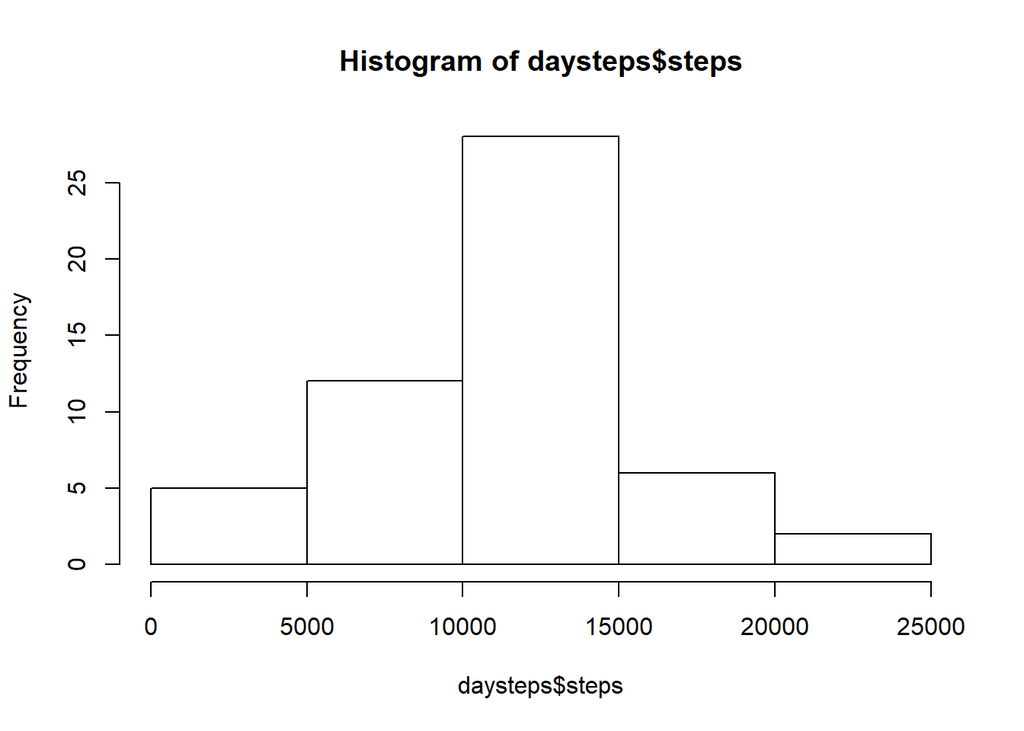

```r
hist(daysteps$steps)
```

3.Calculate and report the mean and median of the total number of steps taken per day

```r
mean_steps <- mean(daysteps$steps)
mean_steps
```

```
## [1] 10766.19
```

```r
median_steps <- median(daysteps$steps)
median_steps
```

```
## [1] 10765
```

## What is the average daily activity pattern?

1.Make a time series plot (i.e. type = “l”type=“l”) of the 5-minute interval (x-axis) and the average number of steps taken, averaged across all days (y-axis)

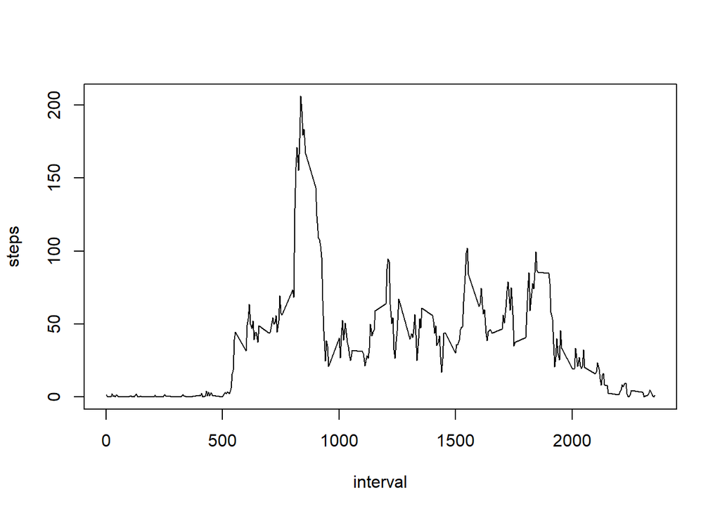

```r
intervalsteps <- aggregate(steps ~ interval, activity, mean, na.rm = TRUE)
plot(steps ~ interval, data = intervalsteps, type= "l")
```

2.Which 5-minute interval, on average across all the days in the dataset, contains the maximum number of steps?

```r
maxsteps <- intervalsteps[which.max(intervalsteps$steps), ]$interval
maxsteps
```

```
## [1] 835
```

## Imputing missing values

1.Calculate and report the total number of missing values in the dataset (i.e. the total number of rows with NANAs)

```r
missing_na <- sum(is.na(activity$steps))
missing_na
```

```
## [1] 2304
```

```r
avgsteps <- with(activity, tapply(steps, date, mean, na.rm = TRUE))
for (i in length(which(is.na(activity$steps)))) {
        activity[which(is.na(activity$steps)), 1] <- mean(avgsteps, na.rm=TRUE)
}
```

3a. Make a histogram of the total number of steps taken each day. What is the impact of imputing missing data on the estimates of the total daily number of steps?

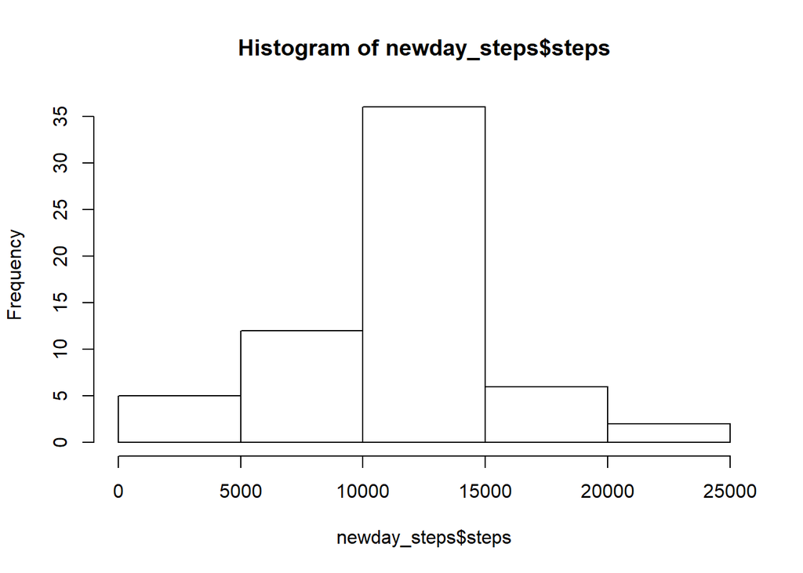

```r
newday_steps <- aggregate(steps ~ date, activity, sum, na.rm = TRUE )
hist(newday_steps$steps)
```

3b.Calculate and report the mean and median total number of steps taken per day. Do these values differ from the estimates from the first part of the assignment?

```r
new_mean_steps <- mean(newday_steps$steps)
new_mean_steps
```

```
## [1] 10766.19
```

```r
new_median_steps <- median(newday_steps$steps)
new_median_steps
```

```
## [1] 10766.19
```

## Are there differences in activity patterns between weekdays and weekends?

1.Create a new factor variable in the dataset with two levels – “weekday” and “weekend” indicating whether a given date is a weekday or weekend day.

```r
activity$day <- ifelse(weekdays(as.Date(activity$date)) == "Samstag" | weekdays(as.Date(activity$date)) == "Sonntag", "weekend", "weekday")
```

2.Make a panel plot containing a time series plot (i.e. type = “l”type=“l”) of the 5-minute interval (x-axis) and the average number of steps taken, averaged across all weekday days or weekend days (y-axis). See the README file in the GitHub repository to see an example of what this plot should look like using simulated data.

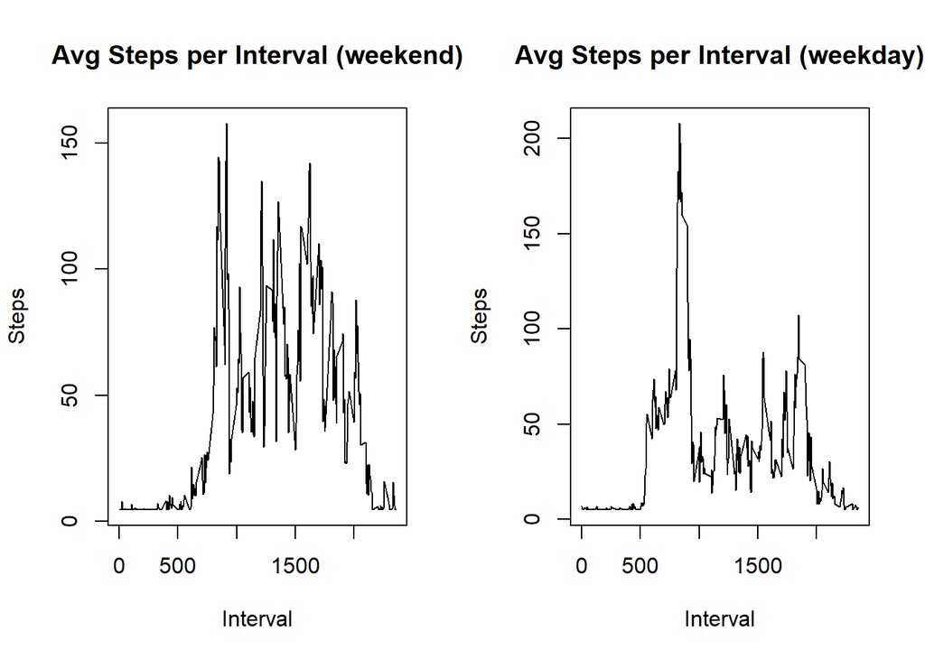

```r
#Calculate avg steps per weekend
avgsteps_wnd <- tapply(activity[activity$day=="weekend",]$steps, activity[activity$day=="weekend",]$interval, mean, na.rm=TRUE)

#Calculate avg steps per weekday
avgsteps_wd <- tapply(activity[activity$day=="weekday",]$steps,activity[activity$day=="weekday",]$interval, mean, na.rm=TRUE)

#Plot
par(mfrow=c(1,2))

plot(as.numeric(names(avgsteps_wnd)), avgsteps_wnd, xlab="Interval", ylab="Steps", main = "Avg Steps per Interval (weekend)", type="l")
plot(as.numeric(names(avgsteps_wd)), avgsteps_wd, xlab="Interval", ylab="Steps", main = "Avg Steps per Interval (weekday)", type="l")
```